# 15_S4

2023-04-17

# 15. S4

## 15.1 Introduction

```r
library(methods)
library(tidyverse)
```

## 15.2 Basics

```r
setClass("Person",
  slots = c(
    name = "character",
    age = "numeric"
  )
)
```

```r
john <- new("Person", name = "John Smith", age = NA_real_)
```

```r
is(john)
```

```
## [1] "Person"
```

```r
john@name
```

```
## [1] "John Smith"
```

```r
slot(john, "age")
```

```
## [1] NA
```

```r
setGeneric("age", function(x) standardGeneric("age"))
```

```
## [1] "age"
```

```r
setGeneric("age<-", function(x, value) standardGeneric("age<-"))
```

```
## [1] "age<-"
```

```r
setMethod("age", "Person", function(x) x@age)
setMethod("age<-", "Person", function(x, value) {
  x@age <- value
  x
})

age(john) <- 50
age(john)
```

```
## [1] 50
```

```r
sloop::otype(john)
```

```
## [1] "S4"
```

```r
sloop::ftype(age)
```

```
## [1] "S4"      "generic"
```

### 15.2.1 Exercises

1. `lubridate::period()` returns an S4 class. What slots does it have? What class is each slot? What accessors does it provide?

```r
myTime <- lubridate::period(c(3, 1, 2, 13, 1), c("second", "minute", "hour", "day", "week"))

myTime
```

```
## [1] "20d 2H 1M 3S"
```

```r
sloop::otype(myTime)
```

```
## [1] "S4"
```

```r
is(myTime)
```

```
## [1] "Period"   "Timespan" "numeric"  "vector"
```

```r
slotNames(myTime)
```

```
## [1] ".Data"  "year"   "month"  "day"    "hour"   "minute"
```

```r
slotNames(myTime) %>%
  map(is)
```

```
## [[1]]
## [1] "character"           "vector"              "data.frameRowLabels"
## [4] "SuperClassMethod"
##
## [[2]]
## [1] "character"           "vector"              "data.frameRowLabels"
## [4] "SuperClassMethod"
##
## [[3]]
## [1] "character"           "vector"              "data.frameRowLabels"
## [4] "SuperClassMethod"
##
## [[4]]
## [1] "character"           "vector"              "data.frameRowLabels"
## [4] "SuperClassMethod"
##
## [[5]]
## [1] "character"           "vector"              "data.frameRowLabels"
## [4] "SuperClassMethod"
##
## [[6]]
## [1] "character"           "vector"              "data.frameRowLabels"
## [4] "SuperClassMethod"
```

```r
str(myTime)
```

```
## Formal class 'Period' [package "lubridate"] with 6 slots
##   ..@ .Data : num 3
##   ..@ year  : num 0
##   ..@ month : num 0
##   ..@ day   : num 20
##   ..@ hour  : num 2
##   ..@ minute: num 1
```

```r
lubridate::month(myTime)
```

```
## [1] 0
```

```r
lubridate::hour(myTime)
```

```
## [1] 2
```

Six slots, accessors same name as slots.

2. What other ways can you find help for a method? Read `?"?"` and summarise the details.

```r
help("lubridate::period")
??lubridate::period
?lubridate::period
methods?lubridate::period
Period?period
```

## 15.3 Classes

```r
setClass("Person",
  slots = c(
    name = "character",
    age = "numeric"
  ),
  prototype = list(
    name = NA_character_,
    age = NA_real_
  )
)

me <- new("Person", name = "Hadley")
str(me)
```

```
## Formal class 'Person' [package ".GlobalEnv"] with 2 slots
##   ..@ name: chr "Hadley"
##   ..@ age : num NA
```

### 15.3.1 Inheritance

```r
setClass("Employee",
  contains = "Person",
  slots = c(
    boss = "Person"
  ),
  prototype = list(
    boss = new("Person")
  )
)

str(new("Employee"))
```

```
## Formal class 'Employee' [package ".GlobalEnv"] with 3 slots
##   ..@ boss:Formal class 'Person' [package ".GlobalEnv"] with 2 slots
##   .. .. ..@ name: chr NA
##   .. .. ..@ age : num NA
##   ..@ name: chr NA
##   ..@ age : num NA
```

### 15.3.2 Introspection

```r
is(new("Person"))
```

```
## [1] "Person"
```

```r
is(new("Employee"))
```

```
## [1] "Employee" "Person"
```

```r
is(john, "Person")
```

```
## [1] TRUE
```

### 15.3.3 Redefinition

```r
setClass("A", slots = c(x = "numeric"))
a <- new("A", x = 10)

setClass("A", slots = c(a_different_slot = "numeric"))
a
```

```
## An object of class "A"
## Slot "a_different_slot":
```

```
## Error in slot(object, what): no slot of name "a_different_slot" for this object of class "A"
```

### 15.3.4 Helper

```r
Person <- function(name, age = NA) {
  age <- as.double(age)

  new("Person", name = name, age = age)
}

Person("Hadley")
```

```
## An object of class "Person"
## Slot "name":
## [1] "Hadley"
##
## Slot "age":
## [1] NA
```

### 15.3.5 Validator

```r
Person(mtcars)
```

```
## Error in validObject(.Object): invalid class "Person" object: invalid object for slot "name" in class "Person": got class "data.frame", should be or extend class "character"
```

```r
Person("Hadley", age = c(30, 37))
```

```
## An object of class "Person"
## Slot "name":
## [1] "Hadley"
##
## Slot "age":
## [1] 30 37
```

```r
setValidity("Person", function(object) {
  if (length(object@name) != length(object@age)) {
    "@name and @age must be same length"
  } else {
    TRUE
  }
})
```

```
## Class "Person" [in ".GlobalEnv"]
##
## Slots:
##
## Name:       name       age
## Class: character   numeric
##
## Known Subclasses: "Employee"
```

```r
Person("Hadley", age = c(30, 37))
```

```
## Error in validObject(.Object): invalid class "Person" object: @name and @age must be same length
```

```r
alex <- Person("Alex", age = 30)
alex@age <- 1:10
alex@age
```

```
##  [1]  1  2  3  4  5  6  7  8  9 10
```

```r
validObject(alex)
```

```
## Error in validObject(alex): invalid class "Person" object: @name and @age must be same length
```

### 15.3.6 Exercises

1. Extend the Person class with fields to match `utils::person()`. Think about what slots you will need, what class each slot should have, and what you’ll need to check in your validity method.

```r
a <- utils::person("John")
str(a)
```

```
## Class 'person'  hidden list of 1
##  $ :List of 5
##   ..$ given  : chr "John"
##   ..$ family : NULL
##   ..$ role   : NULL
##   ..$ email  : NULL
##   ..$ comment: NULL
```

```r
setClass(
  "Person",
  slots = c(
    first_name = "character",
    last_name = "character",
    age = "numeric",
    role = "character",
    email = "character",
    comment = "character"
  ),
  prototype = list(
    first_name = NA_character_,
    last_name = NA_character_,
    age = NA_real_,
    role = NA_character_,
    email = NA_character_,
    comment = NA_character_
  )
)

Person <- function(first_name,
                   last_name = NA,
                   age = NA,
                   role = NA,
                   email = NA,
                   comment = NA) {
  last_name <- as.character(last_name)
  age <- as.double(age)
  role <- as.character(role)
  email <- as.character(email)
  comment <- as.character(comment)

  new(
    "Person",
    first_name = first_name,
    last_name = last_name,
    role = role,
    email = email,
    comment = comment
  )
}

setValidity("Person", function(object) {
  if (length(object@first_name) != 1 |
      length(object@last_name) != 1 |
      length(object@age) != 1 |
      length(object@role) != 1 |
      length(object@email) != 1 |
      length(object@comment) != 1) {
    "@first_name, @last_name, @age, @email, @comment must be length 1"
  } else if (!all(
    object@role %in% c(
      "aut",
      "com",
      "cph",
      "cre",
      "ctb",
      "ctr",
      "dtc",
      "fnd",
      "rev",
      "ths",
      "trl"
    )
  )) {
    '@role must be one of ("aut", "com", "cph", "cre", "ctb", "ctr", "dtc", "fnd", "rev", "ths","trl")'
  } else {
    TRUE
  }
})
```

```
## Class "Person" [in ".GlobalEnv"]
##
## Slots:
##
## Name:  first_name  last_name        age       role      email    comment
## Class:  character  character    numeric  character  character  character
```

```r
John <-
  new(
    "Person",
    first_name = "John",
    last_name = "Davis",
    role = c("asdasd", "asdasdaaaa")
  )
```

```
## Error in validObject(.Object): invalid class "Person" object: @first_name, @last_name, @age, @email, @comment must be length 1
```

```r
John <-
  new("Person",
      first_name = "John",
      last_name = "Davis",
      role = "asdasdaaaa")
```

```
## Error in validObject(.Object): invalid class "Person" object: @role must be one of ("aut", "com", "cph", "cre", "ctb", "ctr", "dtc", "fnd", "rev", "ths","trl")
```

```r
John <-
  new("Person",
      first_name = "John",
      last_name = "Davis",
      role = "aut")
```

2. What happens if you define a new S4 class that doesn’t have any slots? (Hint: read about virtual classes in `?setClass`.)

```r
setClass("Emptiness")

testcase <- new("Emptiness")
```

```
## Error in new("Emptiness"): trying to generate an object from a virtual class ("Emptiness")
```

```r
setClass("Something", contains = "Emptiness")
```

You get an error when trying to make an object using the virtual class. “If the class is virtual, an attempt to generate an object from either the generator or new() will result in an error.” You can inherit it. Apparently common and useful for *class union*

3. Imagine you were going to reimplement factors, dates, and data frames in S4. Sketch out the `setClass()` calls that you would use to define the classes. Think about appropriate slots and prototype.

```r
setClass("MyFactor",
         slots = c(
           values = "integer",
           levels = "character",
           ordered = "logical"
         ),
         prototype = c(
           values = NA_integer_,
           levels = NA_character_,
           ordered = FALSE
         ))

new("MyFactor",
    values = c(1L,10L),
    levels = c("low", "high"),
    ordered = T)
```

```
## An object of class "MyFactor"
## Slot "values":
## [1]  1 10
##
## Slot "levels":
## [1] "low"  "high"
##
## Slot "ordered":
## [1] TRUE
```

```r
setClass("MyDate",
         slots = c(
           date = "integer"
         ),
         prototype = c(
           date = NA_integer_
         ))

new("MyDate", date = 12L)
```

```
## An object of class "MyDate"
## Slot "date":
## [1] 12
```

```r
setClass("MyDataFrame",
         slots = c(
           data = "list",
           row.names = "character"
         ),
         prototype = c(
           data = list(),
           row.names = NA_character_
         ))

new("MyDataFrame",
    data = list(aaa = c(12,53),
                bbb = c(5235,341634),
                ccc = c(334534,4362113)))
```

```
## An object of class "MyDataFrame"
## Slot "data":
## $aaa
## [1] 12 53
##
## $bbb
## [1]   5235 341634
##
## $ccc
## [1]  334534 4362113
##
##
## Slot "row.names":
## [1] NA
```

```r
new("MyDataFrame",
    data = list(aaa = c(12,53),
                bbb = c(5235,341634),
                ccc = c(334534,4362113)),
    row.names = c("This", "is", "bad"))
```

```
## An object of class "MyDataFrame"
## Slot "data":
## $aaa
## [1] 12 53
##
## $bbb
## [1]   5235 341634
##
## $ccc
## [1]  334534 4362113
##
##
## Slot "row.names":
## [1] "This" "is"   "bad"
```

```r
setClass("Person",
  slots = c(
    name = "character",
    age = "numeric"
  )
)
```

```r
john <- new("Person", name = "John Smith", age = NA_real_)
```

## 15.4 Generics and methods

```r
setGeneric("myGeneric", function(x) standardGeneric("myGeneric"))
```

```
## [1] "myGeneric"
```

```r
# Don't do this!
setGeneric("myGeneric", function(x) {
  standardGeneric("myGeneric")
})
```

### 15.4.1 Signature

```r
setGeneric("myGeneric",
  function(x, ..., verbose = TRUE) standardGeneric("myGeneric"),
  signature = "x"
)
```

```
## [1] "myGeneric"
```

### 15.4.2 Methods

```r
setMethod("myGeneric", "Person", function(x) {
  cat("HELP!\n")
})
```

```r
methods("myGeneric")
```

```
## [1] myGeneric,Person-method
## see '?methods' for accessing help and source code
```

```r
methods(class = "Person")
```

```
## [1] age       age<-     myGeneric
## see '?methods' for accessing help and source code
```

```r
selectMethod("myGeneric", "Person")
```

```
## Method Definition:
##
## function (x, ..., verbose = TRUE)
## {
##     .local <- function (x)
##     {
##         cat("HELP!\n")
##     }
##     .local(x, ...)
## }
##
## Signatures:
##         x
## target  "Person"
## defined "Person"
```

### 15.4.3 Show method

```r
args(getGeneric("show"))
```

```
## function (object)
## NULL
```

```r
setMethod("show", "Person", function(object) {
  cat(is(object)[[1]], "\n",
      "  Name: ", object@name, "\n",
      "  Age:  ", object@age, "\n",
      sep = ""
  )
})
john
```

```
## Person
##   Name: John Smith
##   Age:  NA
```

### 15.4.4 Accessors

```r
person_name <- function(x) x@name
```

```r
setGeneric("name", function(x) standardGeneric("name"))
```

```
## [1] "name"
```

```r
setMethod("name", "Person", function(x) x@name)

name(john)
```

```
## [1] "John Smith"
```

```r
setValidity("Person", function(object) {
  if (length(object@name) != length(object@age)) {
    "@name and @age must be same length"
  } else if (!is.numeric(object@age)) {
    "@age must be a numeric value"
  }
  else {
    TRUE
  }
})
```

```
## Class "Person" [in ".GlobalEnv"]
##
## Slots:
##
## Name:       name       age
## Class: character   numeric
```

```r
setGeneric("name<-", function(x, value) standardGeneric("name<-"))
```

```
## [1] "name<-"
```

```r
setMethod("name<-", "Person", function(x, value) {
  x@name <- value
  validObject(x)
  x
})

name(john) <- "Jon Smythe"
name(john)
```

```
## [1] "Jon Smythe"
```

```r
name(john) <- letters
```

```
## Error in validObject(x): invalid class "Person" object: @name and @age must be same length
```

```r
name(john)
```

```
## [1] "Jon Smythe"
```

### 15.4.5 Exercises

1. Add `age()` accessors for the Person class.

```r
setGeneric("age", function(x) standardGeneric("age"))
```

```
## [1] "age"
```

```r
setMethod("age", "Person", function(x) x@age)
setGeneric("age<-", function(x, value) standardGeneric("age<-"))
```

```
## [1] "age<-"
```

```r
setMethod("age<-", "Person", function(x, value) {
  x@age <- value
  validObject(x)
  x
})

age(john)
```

```
## [1] NA
```

```r
age(john) <- 29
age(john)
```

```
## [1] 29
```

```r
age(john) <- "Twenty nine"
```

```
## Error in (function (cl, name, valueClass) : assignment of an object of class "character" is not valid for @'age' in an object of class "Person"; is(value, "numeric") is not TRUE
```

2. In the definition of the generic, why is it necessary to repeat the name of the generic twice?

We use `setGeneric()` to define a generic in S4. The `name` is used in both with the first for defining the generic and the second in `standardGeneric()` for method dispatch to work correctly. `standardGeneric()` is the default method for our new generic. The body of a generic function usually does nothing except for dispatching methods by a call to `standardGeneric`. Under some circumstances you might just want to do some additional computation in the generic function itself. As long as your function eventually calls `standardGeneric` that is permissible

3. Why does the `show()` method defined in Section 15.4.3 use `is(object)[[1]]`? (Hint: try printing the employee subclass.)

```r
is(new("Employee"))
```

```
## [1] "Employee" "Person"
```

```r
is(new("Employee"))[[1]]
```

```
## [1] "Employee"
```

```r
poor <- new("Employee", name = "Trash")
poor
```

```
## Employee
##   Name: Trash
##   Age:  NA
```

```r
is(poor)
```

```
## [1] "Employee" "Person"
```

```r
is(poor)[[1]]
```

```
## [1] "Employee"
```

Subsetting on the first entry is done in order to prevent printing all the classes the class also inherits from.

4. What happens if you define a method with different argument names to the generic?

```r
setGeneric("age2", function(x) standardGeneric("age2"))
```

```
## [1] "age2"
```

```r
setMethod("age2", "Person", function(aaa) {
  cat("SOME TEXT and an age", aaa@age, "\n")
})
```

```
## Warning: For function 'age2', signature 'Person': argument in method definition
## changed from (aaa) to (x)
```

```r
age2(john)
```

```
## SOME TEXT and an age 29
```

It warns us that we changed it.

## 15.5 Method dispatch

### 15.5.1 Single dispatch

### 15.5.2 Multiple inheritance

### 15.5.3 Multiple dispatch

### 15.5.4 Multiple dispatch and multiple inheritance

### 15.5.5 Exercises

1. Draw the method graph for `f(😅, 😽)`.

I’m not drawing all those combos

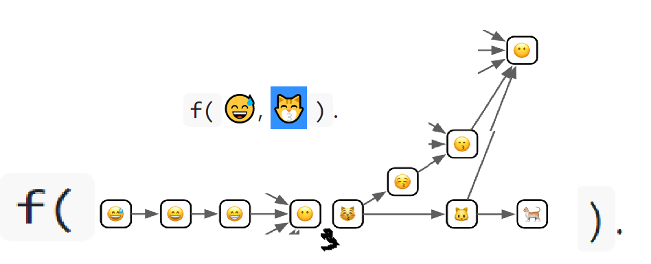

exercise 1

2. Draw the method graph for `f(😃, 😉, 😙)`.

Lol No

3. Take the last example which shows multiple dispatch over two classes that use multiple inheritance. What happens if you define a method for all terminal classes? Why does method dispatch not save us much work here?

There’s total of 9 possible methods for this combination with 4 of them being terminal classes. We’d just define the other 5 combinations at this point to avoid ambiguity.

## 15.6 S4 and S3

### 15.6.1 Classes

```r
setOldClass("data.frame")
setOldClass(c("ordered", "factor"))
setOldClass(c("glm", "lm"))
```

```r
setClass("factor",
  contains = "integer",
  slots = c(
    levels = "character"
  ),
  prototype = structure(
    integer(),
    levels = character()
  )
)
setOldClass("factor", S4Class = "factor")
RangedNumeric <- setClass(
  "RangedNumeric",
  contains = "numeric",
  slots = c(min = "numeric", max = "numeric"),
  prototype = structure(numeric(), min = NA_real_, max = NA_real_)
)
rn <- RangedNumeric(1:10, min = 1, max = 10)
rn@min
```

```
## [1] 1
```

```r
rn@.Data
```

```
##  [1]  1  2  3  4  5  6  7  8  9 10
```

```r
str(rn)
```

```
## Formal class 'RangedNumeric' [package ".GlobalEnv"] with 3 slots
##   ..@ .Data: int [1:10] 1 2 3 4 5 6 7 8 9 10
##   ..@ min  : num 1
##   ..@ max  : num 10
```

### 15.6.2 Generics

```r
setGeneric("mean")
```

```
## [1] "mean"
```

```r
selectMethod("mean", "ANY")
```

```
## Method Definition (Class "derivedDefaultMethod"):
##
## function (x, ...)
## UseMethod("mean")
## <bytecode: 0x000001d10d9301e8>
## <environment: namespace:base>
##
## Signatures:
##         x
## target  "ANY"
## defined "ANY"
```

### 15.6.3 Exercises

1. What would a full `setOldClass()` definition look like for an ordered factor (i.e. add `slots` and `prototype` the definition above)?

```r
setClass("OrderedFactor",
  contains = "factor",
  slots = c(
    levels = "character",
    ordered = "logical"
  ),
  prototype = structure(
    integer(),
    levels = character(),
    ordered = logical()
  )
)

setOldClass("ordered", S4Class = "OrderedFactor")
```

2. Define a `length` method for the Person class.

```r
setMethod("length", "Person", function(x) {
  cat("BRUH WE DIDN'T INCLUDE THIS SLOT\n")
})

length(john)
```

```
## BRUH WE DIDN'T INCLUDE THIS SLOT
```